# Mistranslation analysis

Sinisa Bratulic

11 May, 2021

# 1 Setup

```r
library(knitr)
library(tidyverse)
library(readxl)
library(janitor)
library(seqinr)
```

## 1.1 Load the CAI data

Load E. coli codon adaptation index table - data is from the *seqinr* package, cited below, originally published in: Sharp, P.M., Li, W.-H. (1987) Nucleic Acids Research, 15:1281-1295.

```r
data(caitab)
caitab <- caitab %>% rownames_to_column(var = "Codon")
caitab <- caitab %>% select(Codon, cai = ec)
knitr::kable(list(caitab[1:16,],
           caitab[17:32,],
           caitab[33:48,],
           caitab[49:64,]),
           booktabs = TRUE, valign = 't')
```

| Codon | cai |
| --- | --- |
| aaa | 1.000 |
| aac | 1.000 |
| aag | 0.253 |
| aat | 0.051 |
| aca | 0.076 |
| acc | 1.000 |
| acg | 0.099 |
| act | 0.965 |
| aga | 0.004 |
| agc | 0.410 |
| agg | 0.002 |
| agt | 0.085 |
| ata | 0.003 |
| atc | 1.000 |
| atg | 1.000 |
| att | 0.185 |

|  | Codon | cai |
| --- | --- | --- |
| 17 | caa | 0.124 |
| 18 | cac | 1.000 |
| 19 | cag | 1.000 |
| 20 | cat | 0.291 |
| 21 | cca | 0.135 |
| 22 | ccc | 0.012 |
| 23 | ccg | 1.000 |
| 24 | cct | 0.070 |
| 25 | cga | 0.004 |
| 26 | cgc | 0.356 |
| 27 | cgg | 0.004 |
| 28 | cgt | 1.000 |
| 29 | cta | 0.007 |
| 30 | ctc | 0.037 |
| 31 | ctg | 1.000 |
| 32 | ctt | 0.042 |

|  | Codon | cai |
| --- | --- | --- |
| 33 | gaa | 1.000 |
| 34 | gac | 1.000 |
| 35 | gag | 0.259 |
| 36 | gat | 0.434 |
| 37 | gca | 0.586 |
| 38 | gcc | 0.122 |
| 39 | gcg | 0.424 |
| 40 | gct | 1.000 |
| 41 | gga | 0.010 |
| 42 | ggc | 0.724 |
| 43 | ggg | 0.019 |
| 44 | ggt | 1.000 |
| 45 | gta | 0.495 |
| 46 | gtc | 0.066 |
| 47 | gtg | 0.221 |
| 48 | gtt | 1.000 |

|  | Codon | cai |
| --- | --- | --- |
| 49 | taa | 0.000 |
| 50 | tac | 1.000 |
| 51 | tag | 0.000 |
| 52 | tat | 0.239 |
| 53 | tca | 0.077 |
| 54 | tcc | 0.744 |
| 55 | tcg | 0.017 |
| 56 | tct | 1.000 |
| 57 | tga | 0.000 |
| 58 | tgc | 1.000 |
| 59 | tgg | 1.000 |
| 60 | tgt | 0.500 |
| 61 | tta | 0.020 |
| 62 | ttc | 1.000 |
| 63 | ttg | 0.020 |
| 64 | ttt | 0.296 |

```r
citation("seqinr")
```

```
##
##
##   Charif, D. and Lobry, J.R. (2007)
##
## A BibTeX entry for LaTeX users is
##
##   @InCollection{,
##     author = {D. Charif and J.R. Lobry},
##     title = {Seqin{R} 1.0-2: a contributed package to the {R} project for statistical computing devoted to biological sequences retrieval and analysis.},
##     booktitle = {Structural approaches to sequence evolution: Molecules, networks, populations},
##     year = {2007},
##     editor = {U. Bastolla and M. Porto and H.E. Roman and M. Vendruscolo},
##     series = {Biological and Medical Physics, Biomedical Engineering},
##     pages = {207-232},
##     address = {New York},
##     publisher = {Springer Verlag},
##     note = {{ISBN :} 978-3-540-35305-8},
##   }
```

## 1.2 Load and process sfGFP sequence

```r
gfp_n <- seqinr::read.fasta(file = "data/sfGFPn.fasta")
df_seq <- data.frame(Codon = splitseq(gfp_n$sfGFP)) %>%
  left_join(caitab %>% select(Codon, cai)) %>%
  mutate(cai_roll = zoo::rollmean(cai, k = 3, fill = NA))
df_seq$Codon_c <- lapply(df_seq$Codon, s2c)
df_seq$AA <- sapply(df_seq$Codon_c, translate)
df_seq <-df_seq %>% rowid_to_column(var = "Position") %>%
  group_by(Codon) %>% mutate(nGFP = n()) %>% ungroup()
```

## 1.3 Show CAI

Rolling mean calculated over a window of 3 codons. Rolling mean is shown as a line, and CAI as colors.

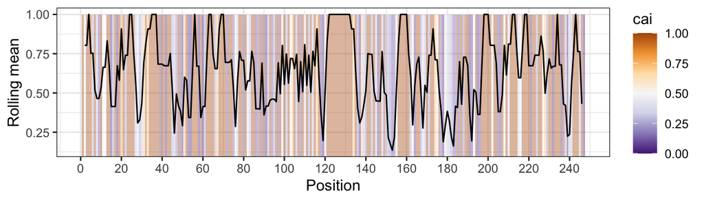

```r
df_seq %>%
  mutate(Codon = str_to_upper(Codon),
         #Position = paste(Position, Codon, AA)
         ) %>%
  ggplot(aes(x = Position, fill = cai)) +
  geom_rect(ymin=0, ymax=1, aes(xmin = Position -0.5, xmax = Position + 0.5), alpha = 0.4) +
  geom_line(aes(y = cai_roll))+
  theme_bw()+
  scale_fill_distiller(palette = "PuOr")+
  scale_x_continuous(breaks = seq(0,250,20))+
  #theme(axis.text.x = element_text(hjust = 1, vjust = 1)) +
  ylab("Rolling mean")
```

## 1.4 Load and process manuscript data 1

```r
filepos <- "data/Sub_AA_sfGFP_SuppFig6DE.xlsx"
sheets_pos <- excel_sheets(filepos)
df_pos <- lapply(sheets_pos,function(x) read_xlsx(filepos, sheet=x)) %>%
  bind_cols() %>%
  clean_names() %>%
  select(-sf_gfp_amino_acid_residue_n_c_10)
colnames(df_pos)[1] <- "Position"

head(df_pos)
```

| Position | wild_type_ec | ec_2_5 | ec_2_6 | ec_s3_1 | ec_s3_5 | ec_s3_7 | ec_s4_4 | ec_s4_7 | vc_start | vc_2_4 | vc_2_7 | vc_s3_1 | vc_s3_7 | vc_s4_4 | vc_s4_5 |
| --- | --- | --- | --- | --- | --- | --- | --- | --- | --- | --- | --- | --- | --- | --- | --- |
| 1 | NA | NA | NA | NA | NA | NA | NA | NA | NA | NA | NA | NA | NA | NA | NA |
| 2 | NA | NA | NA | NA | NA | NA | 4.209764 | NA | 0.01040349 | NA | NA | NA | NA | NA | NA |
| 3 | NA | NA | NA | NA | NA | NA | NA | NA | NA | NA | NA | NA | NA | NA | NA |
| 4 | 0.0364 | NA | NA | NA | NA | NA | NA | 0.035261 | NA | NA | 0.02650595 | NA | NA | NA | NA |
| 5 | NA | NA | NA | NA | NA | NA | NA | NA | NA | NA | NA | NA | NA | NA | NA |
| 6 | NA | NA | NA | NA | NA | NA | NA | NA | NA | NA | NA | NA | NA | NA | NA |

```r
df_pos_l <- df_pos %>%
  select(-contains("residue")) %>%
  pivot_longer(cols = -Position,
               names_to = "Variant",
               values_to = "Freq") %>%
  mutate(Species = if_else(str_detect(Variant, "ec"), "Ec", "Vc"),
         Evolved = if_else(str_detect(Variant, "wild|start"), FALSE, TRUE),
         Segment = if_else(!Evolved,
                           "0",
                           str_replace(Variant, "^.._s*(\\d)_.*","\\1")),
         Variant = factor(Variant)
  ) %>% distinct() %>%
  left_join(df_seq %>% select(Position, Codon, AA, cai, cai_roll, nGFP))
  #mutate(Freq_i = if_else(is.na(Freq), 0, Freq))
df_pos_l %>% distinct(Variant, Species, Evolved, Segment)
```

| Variant | Species | Evolved | Segment |
| --- | --- | --- | --- |
| wild_type_ec | Ec | FALSE | 0 |
| ec_2_5 | Ec | TRUE | 2 |
| ec_2_6 | Ec | TRUE | 2 |
| ec_s3_1 | Ec | TRUE | 3 |
| ec_s3_5 | Ec | TRUE | 3 |
| ec_s3_7 | Ec | TRUE | 3 |
| ec_s4_4 | Ec | TRUE | 4 |
| ec_s4_7 | Ec | TRUE | 4 |
| vc_start | Vc | FALSE | 0 |
| vc_2_4 | Vc | TRUE | 2 |

[output cut: 5 more lines]

# 2 Exploratory analysis

## 2.1 Aggregate plots

- make histograms and beeswarm plots - only show measured frequencies

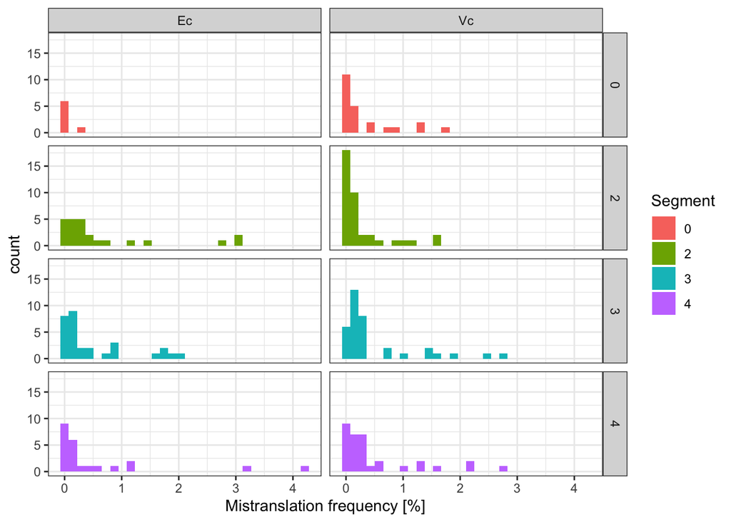

```r
df_pos_l %>%
  ggplot(aes(x = Freq, fill = Segment)) +
  geom_histogram(bins = 30, position = "dodge")+
  facet_grid(Segment~Species) + theme_bw() +
  xlab("Mistranslation frequency [%]") +
  ggsave(device = "svg", filename = "Figs/fig1.svg")
```

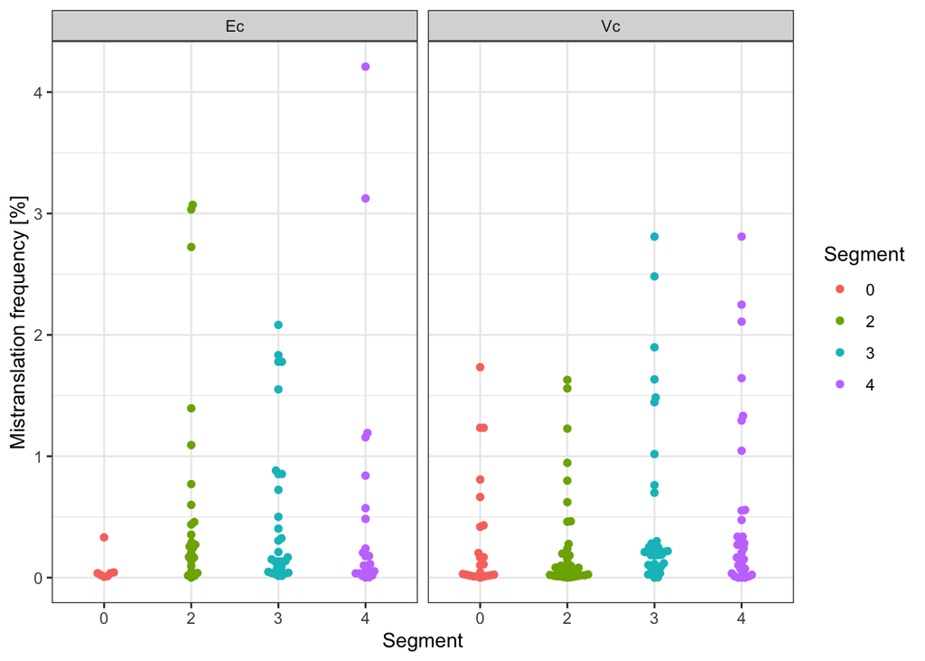

```r
df_pos_l %>%
  ggplot(aes(x = Segment, y = Freq, color = Segment)) +
  ggbeeswarm::geom_beeswarm()+
  facet_wrap(~Species) +
  theme_bw()+
  ylab("Mistranslation frequency [%]") +
  ggsave(device = "svg", filename = "Figs/fig2.svg")
```

## 2.2 Mistranslation profile vs the CAI

- only show measured rates

Calculate Spearman rank correlation for mistranslation frequency vs CAI

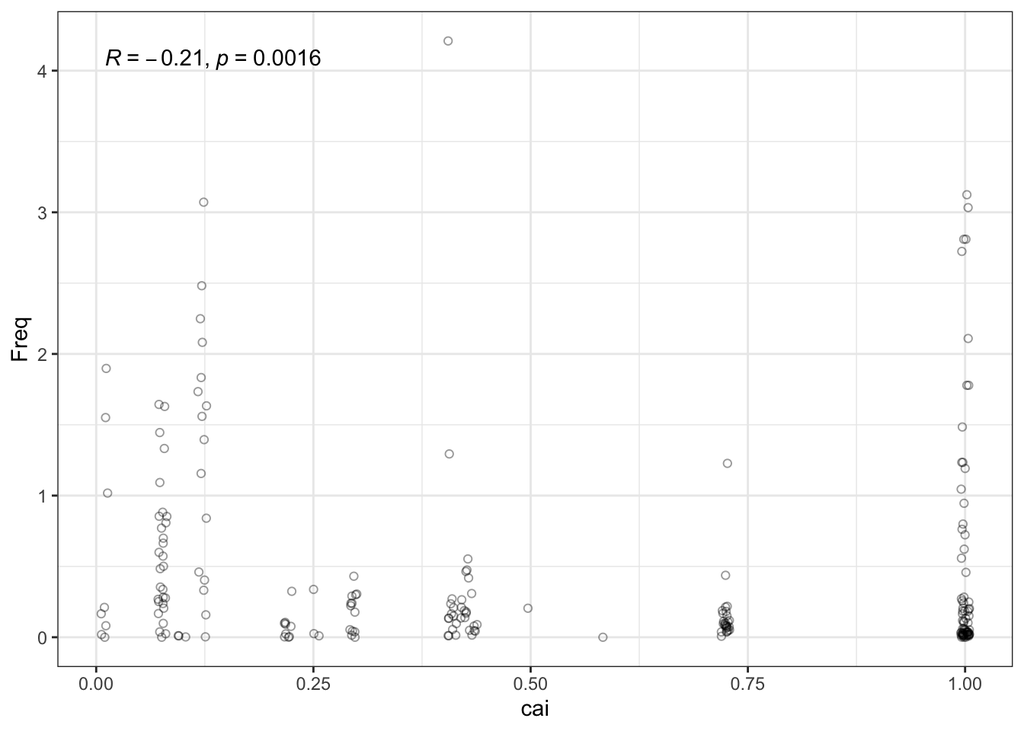

```r
library(ggpubr)
df_pos_l %>%
  ggplot(aes(x = cai, y = Freq)) +
  geom_jitter(alpha = 0.4, width = 0.005, shape = 21) +
  stat_cor(method = "spearman")+
  theme_bw() +
  ggsave(device = "svg", filename = "Figs/fig3.svg")
```

Weak to no correlation.

## 2.3 Mistranslation profile vs the CAI (with imputed unobserved mistranslation freqs)

What if we consider positions where no mistranslation was observed?

E.g. impute missing values based on LOD.

LOD estimated as 1/10 of the lowest observed mistranslation frequency

```r
(LOD <- df_pos_l %>% filter(Freq >0) %>% pull(Freq) %>% min/10)
```

```
## [1] 7.5911e-06
```

```r
df_pos_l <- df_pos_l %>% mutate(Freq_l = if_else(is.na(Freq) | Freq == 0, LOD, Freq))
head(df_pos_l)
```

| Position | Variant | Freq | Species | Evolved | Segment | Codon | AA | cai | cai_roll | nGFP | Freq_l |
| --- | --- | --- | --- | --- | --- | --- | --- | --- | --- | --- | --- |
| 1 | wild_type_ec | NA | Ec | FALSE | 0 | atg | M | 1 | NA | 5 | 7.5911e-06 |
| 1 | ec_2_5 | NA | Ec | TRUE | 2 | atg | M | 1 | NA | 5 | 7.5911e-06 |
| 1 | ec_2_6 | NA | Ec | TRUE | 2 | atg | M | 1 | NA | 5 | 7.5911e-06 |
| 1 | ec_s3_1 | NA | Ec | TRUE | 3 | atg | M | 1 | NA | 5 | 7.5911e-06 |
| 1 | ec_s3_5 | NA | Ec | TRUE | 3 | atg | M | 1 | NA | 5 | 7.5911e-06 |
| 1 | ec_s3_7 | NA | Ec | TRUE | 3 | atg | M | 1 | NA | 5 | 7.5911e-06 |

Calculate Spearman rank correlation for mistranslation frequency vs CAI

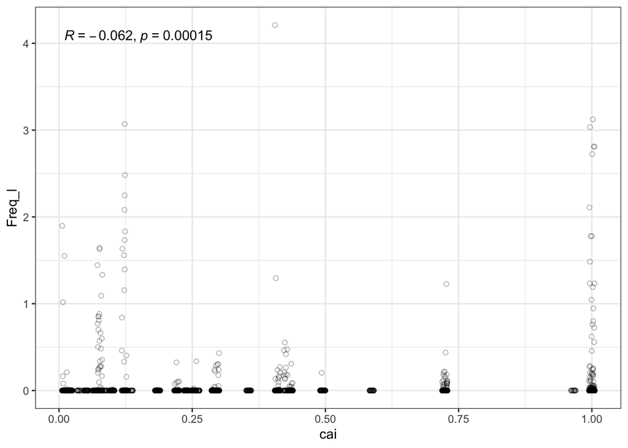

```r
df_pos_l %>%
  ggplot(aes(x = cai, y = Freq_l)) +
  geom_jitter(alpha = 0.3, width = 0.005, shape = 21) +
  stat_cor(method = "spearman")+
  theme_bw()+
  ggsave(device = "svg", filename = "Figs/fig4.svg")
```

## 2.4 Show rolling CAI vs mistranslation frequencies

Rolling mean of CAI rescaled to (-4,0) range for plotting.

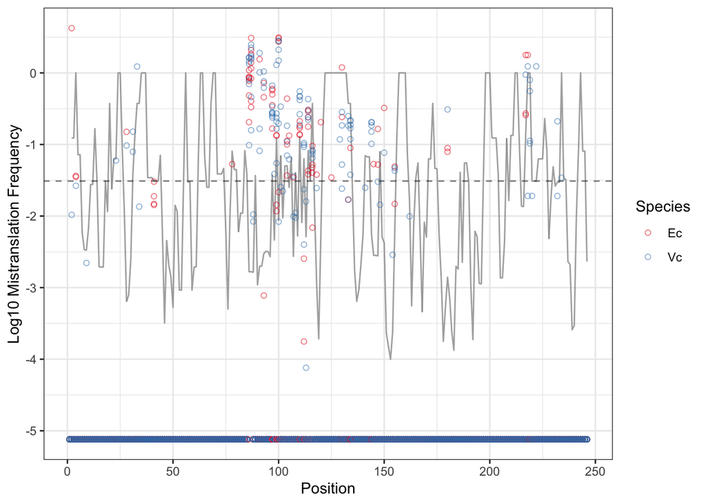

```r
df_pos_l %>%
  mutate(cai_roll = scales::rescale(cai_roll, to = c(-4,0))) %>%
  ggplot(aes(x = Position, y = log10(Freq_l), color = Species)) +
  geom_line(aes(y = cai_roll),color = "grey60", alpha = 0.8) +
  geom_hline(yintercept = median(scales::rescale(df_seq$cai_roll, to = c(-4,0)), na.rm = T),
             linetype = "dashed", alpha = 0.5) +
    geom_point(shape = 21, alpha = 0.5) +
  theme_bw() +
  scale_color_brewer(palette = "Set1") +
  ylab("Log10 Mistranslation Frequency") +
  ggsave(device = "svg", filename = "Figs/fig6.svg")
```

Overall, these CAI vs mistranslation correlation estimates are highly biased. sfGFP sequence is codon optimized and on average has a high CAI:

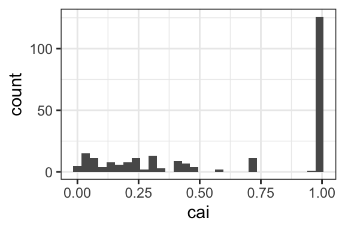

```r
df_pos_l %>%
  distinct(Position, cai) %>%
  ggplot(aes(x = cai)) +
  geom_histogram() +
  theme_bw()+
  ggsave(device = "svg", filename = "Figs/fig5.svg")
```

## 2.5 Hierachical clustering based on observed mistranslated position/rate

```r
library(tidyHeatmap)
df_h <- df_pos_l %>% filter(!is.na(Freq)) %>%
  select(Position, Variant, Freq) %>%
  pivot_wider(names_from = "Variant", values_from = "Freq") %>%
  pivot_longer(cols = -c(Position),
               names_to = "Variant") %>%
  mutate(value =if_else(is.na(value), 0, value)) %>%
  left_join(df_pos_l %>% select(-Freq) %>% distinct())
svg("Figs/fig7.svg")
fig7<-df_h %>% mutate(Position = paste(Position, Codon, AA)) %>%
  tidyHeatmap::heatmap(.row = Position,
                     .column = Variant,
                     .value = value,
                     #transform = log10,
                     palette_value = circlize::colorRamp2(c(-3, -1.5, 0, 1.5, 3), viridis::magma(5))
) %>%
  add_tile(Species) %>%
  add_tile(Segment) %>%
  add_bar(cai)
fig7
dev.off()
```

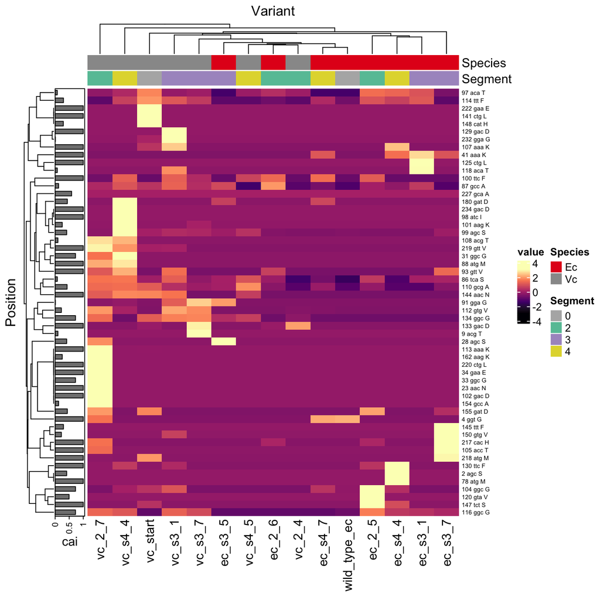

```r
fig7
```

## 2.6 PCA based on observed mistranslated position/frequency

```r
library(FactoMineR)
library(broom)
df_t <- df_h %>%
  filter(Position != 227) %>%
  select(Position, Variant, value) %>%
  pivot_wider(names_from = "Position", values_from = "value") %>%
  left_join(df_h %>% distinct(Variant, Species, Evolved, Segment))
```

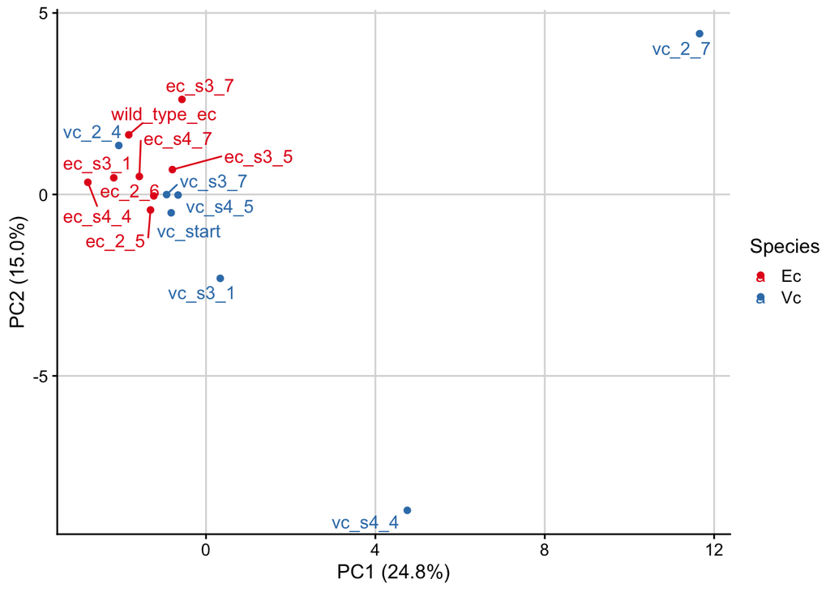

```r
pca_fit <- df_t %>%
  select(where(is.numeric)) %>%
  scale() %>%
  prcomp()
sp<-summary(pca_fit)
pca_fit %>%
  augment(df_t) %>% # add original dataset back in
  ggplot(aes(.fittedPC1, .fittedPC2, color = Species)) +
  geom_point(size = 1.5) +
  cowplot::theme_half_open(12) + cowplot::background_grid() +
  ggrepel::geom_text_repel(aes(label = Variant),  max.overlaps =20)+
  scale_color_brewer(palette = "Set1") +
  xlab(sprintf("PC1 (%2.1f%%)",sp$importance[2,1:2][[1]]*100)) +
  ylab(sprintf("PC2 (%2.1f%%)",sp$importance[2,1:2][[2]]*100)) +
  ggsave(device = "svg", filename = "Figs/fig8.svg")
```

## 2.7 Which positions contribute the most to the separation

```r
library(factoextra)
var_pca <- get_pca(pca_fit)
message("Top 5 positions contributing to PC1:")
```

```
## Top 5 positions contributing to PC1:
```

```r
sort(var_pca$contrib[,1], decreasing = T)[1:5]
```

```
##      219      108       23       34      162
## 7.012910 6.569677 5.807112 5.807112 5.807112
```

```r
message("Top 5 positions contributing to PC2:")
```

```
## Top 5 positions contributing to PC2:
```

```r
sort(var_pca$contrib[,2], decreasing = T)[1:5]
```

```
##       99      101       98      234      180
## 9.137233 8.854173 8.808433 8.808433 7.708417
```

# 3 Mistranslation profile analysis

## 3.1 Load the data

```r
filemt <- "data/Sub_AA_sfGFP_SuppFig6F.xlsx"
mt_sheets <- excel_sheets(filemt)
l_mt <- lapply(mt_sheets, function(x) read_xlsx(filemt, sheet=x))
names(l_mt) <- mt_sheets
df_mt <- bind_rows(l_mt, .id = "ID") %>%
  mutate(Codon = if_else(is.na(Codon), `Codon (down)`, Codon)) %>%
  select(-contains("misin"),-contains("down")) %>%
  mutate(Variant = str_remove_all(ID, "Supp Fig.. "))

df_mt_l <- df_mt %>% select(-ID) %>%
  pivot_longer(cols = -c(Variant, Codon),
               names_to = "AA_mis",
               values_to = "Freq")
```

## 3.2 PCA analysis of mistranslation profile

Sum of mistranslation rates for each codon into an aggregate ‘mistranslation profile’.

Decompose the profile by PCA.

```r
df_t_mt <- df_mt_l %>%
  filter(!is.na(Freq)) %>%
  group_by(Codon, Variant) %>% summarise(sumF = sum(Freq), .groups = "drop") %>%
  left_join(df_seq %>% distinct(Codon, AA) %>% mutate(Codon = str_to_upper(str_replace_all(Codon, "t","u")))) %>%
  mutate(Codon = paste(Codon, AA)) %>%
  select(-AA) %>%
  pivot_wider(names_from = "Codon", values_from = "sumF", values_fill = 0) %>%
  mutate(Species = if_else(str_detect(Variant, "Ec"), "Ec", "Vc"))
```

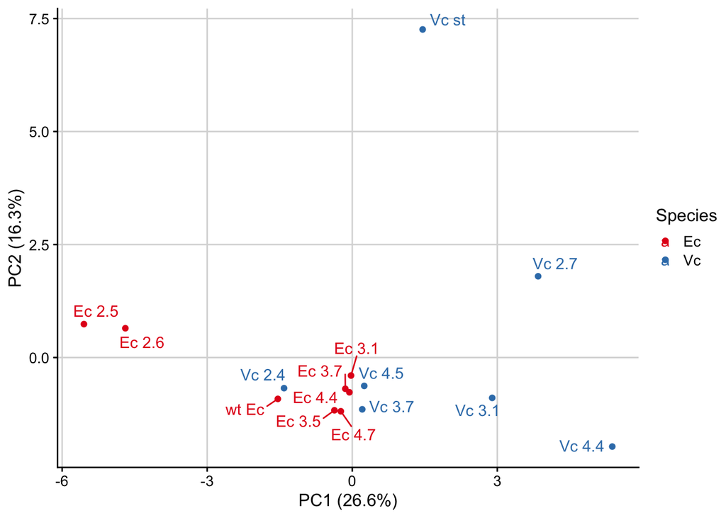

```r
pca_fitmt <- df_t_mt %>%
  select(where(is.numeric)) %>%
  scale() %>%
  prcomp()
sp2<-summary(pca_fitmt)
pca_fitmt  %>%
  augment(df_t_mt) %>% # add original dataset back in
  ggplot(aes(.fittedPC1, .fittedPC2, color = Species)) +
  geom_point(size = 1.5) +
  cowplot::theme_half_open(12) + cowplot::background_grid() +
  ggrepel::geom_text_repel(aes(label = Variant), max.overlaps =20, force = 15) +
  scale_color_brewer(palette = "Set1")+
  xlab(sprintf("PC1 (%2.1f%%)",sp2$importance[2,1:2][[1]]*100)) +
  ylab(sprintf("PC2 (%2.1f%%)",sp2$importance[2,1:2][[2]]*100)) +
  ggsave(device = "svg", filename = "Figs/fig9.svg")
```

## 3.3 Which codons contribute the most to separation of mistranslation profiles?

```r
var_pca_mt <- get_pca(pca_fitmt)
message("Top 5 Codons contributing to PC1:")
```

```
## Top 5 Codons contributing to PC1:
```

```r
sort(var_pca_mt$contrib[,1], decreasing = T)[1:5]
```

```
##    UCA S    AAC N    GCG A    GUU V    GCC A
## 8.762929 7.570374 7.340184 7.035592 6.830776
```

```r
message("Top 5 Codons contributing to PC2:")
```

```
## Top 5 Codons contributing to PC2:
```

```r
sort(var_pca_mt$contrib[,2], decreasing = T)[1:5]
```

```
##    AUG M    GAA E    CAU H    CUG L    GCA A
## 18.38136 17.05235 16.80963 16.09647 11.17627
```

## 3.4 Clustering based on mistranslation profile

```r
svg("Figs/fig10.svg")
fig10 <- df_t_mt %>%
  pivot_longer(cols = -c(Variant, Species), names_to = "Codon", values_to = "Freq") %>%
  tidyHeatmap::heatmap(.row = Codon,
                     .column = Variant,
                     .value = Freq,
                     #transform = log10,
                     palette_value = circlize::colorRamp2(c(-3, -1.5, 0, 1.5, 3), viridis::magma(5))
) %>%
  add_tile(Species)
fig10
dev.off()
```

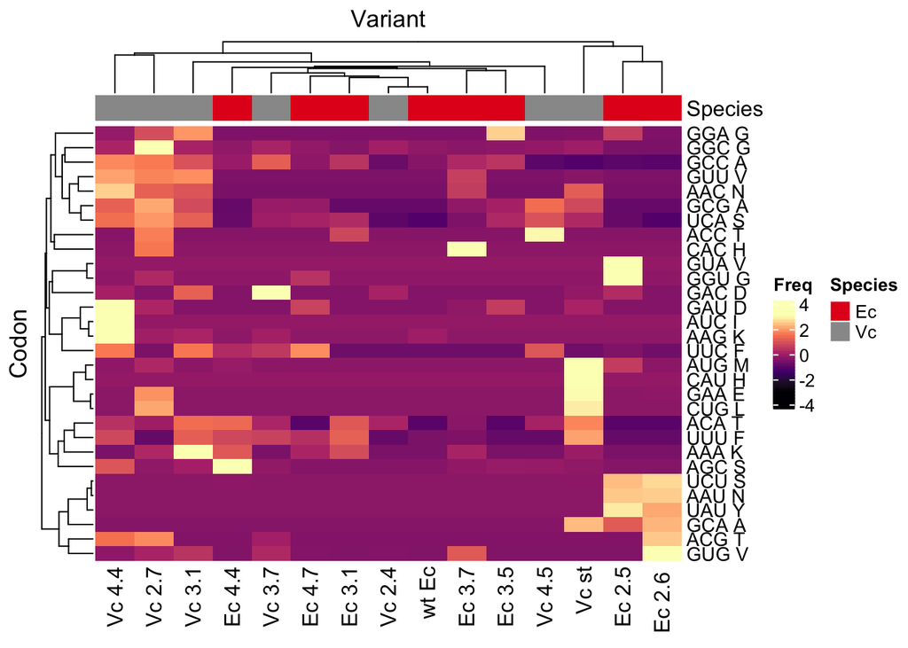

```r
fig10
```